# STA 472 2.0 Special Topics in Statistics

Sadrushi Dissanayake (AS2018346)

## Analysis of COVID-19 pandemic for USA

#### **Figure 1: Top 10 countries by number of reported COVID-19 deaths as of August 16, 2021**

[interactive chart not shown]

Figure 1 depicts the top 10 countries which have reported highest number of covid deaths as of 16th August 2021. Out of the top countries United States reported the highest number of death cases while Brazil and India reported second and third highest cumulative number of death cases. When compared to other countries lower number of deaths were reported for United Kingdom, Italy, Indonesia and Colombia.

#### **Figure 2: Total COVID-19 related hospitalizations for USA by Hispanic/Non-Hispanic ethnicity and state**

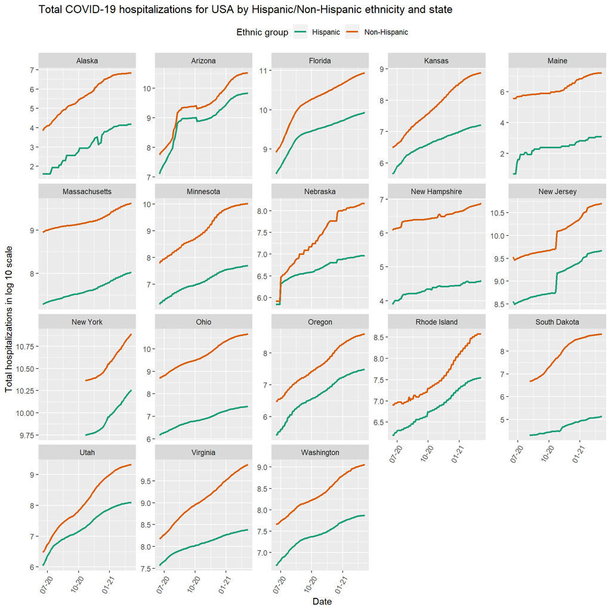

#### **Figure 3: COVID-19 death cases for United States by state and racial group**

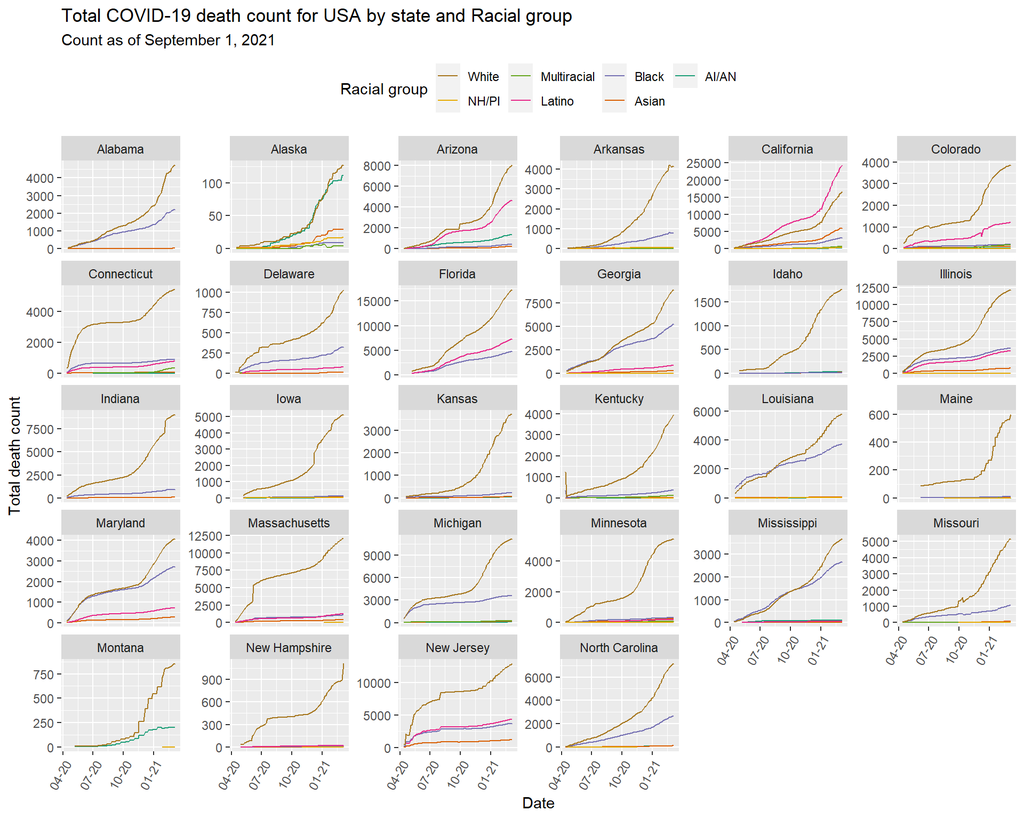

According to figure 3 white people had the highest total corona death cases for allmost all the states. In Alaska covid deaths were nearly same for white people and American Indian or Alaska Native (AI/AN) for time between July 2020 and January 2021. In contrast California reported highest number of total covid-19 deaths for Latino people than white people. Hence when compared across America majority of white people lost many lives because of covid-19.

#### **Figure 4: How different causes of deaths in United States change over year 2014 to 2021**

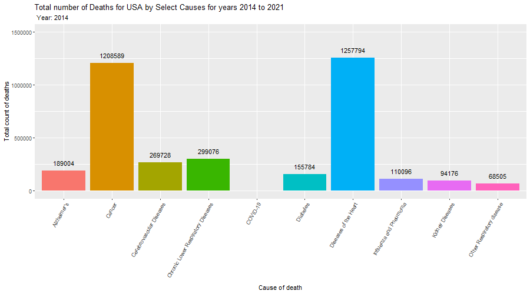

#### **References:**

[State Abbreviations for the 50 US States](https://www.50states.com/abbreviations.htm)